# Lab 04: Not Team 1

David Orozco, Arie del Valle, Ethan Schacht, Ryan Tate

February 8, 2019

### David’s Graph

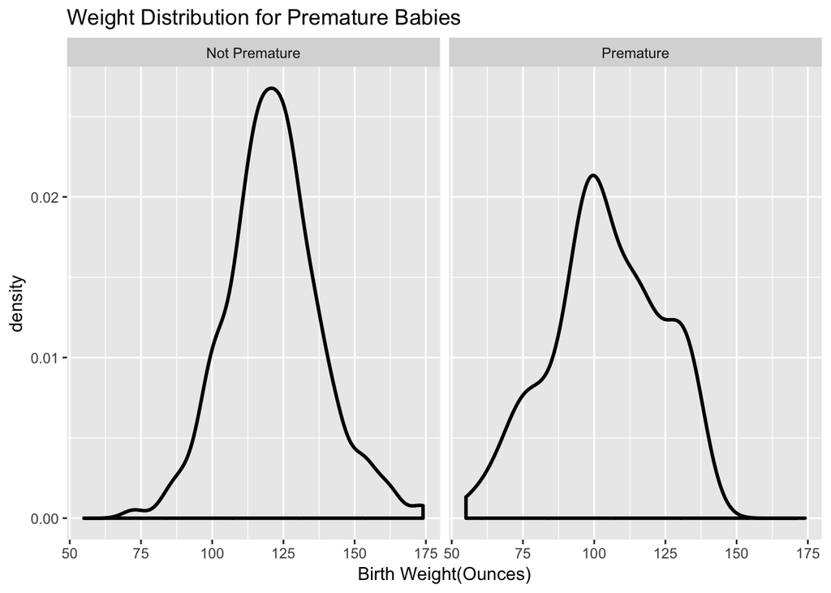

- I used geom_density to show the distribution of birth weight in ounces. I used facet command to show differences in the distribution based on whether or not the baby was premature. ( Premature is born before gestational age of 270)
- The mean of the distribution for birth weight of premature babies (~100) is the smallest of the two distributions.

### Arie’s Graph

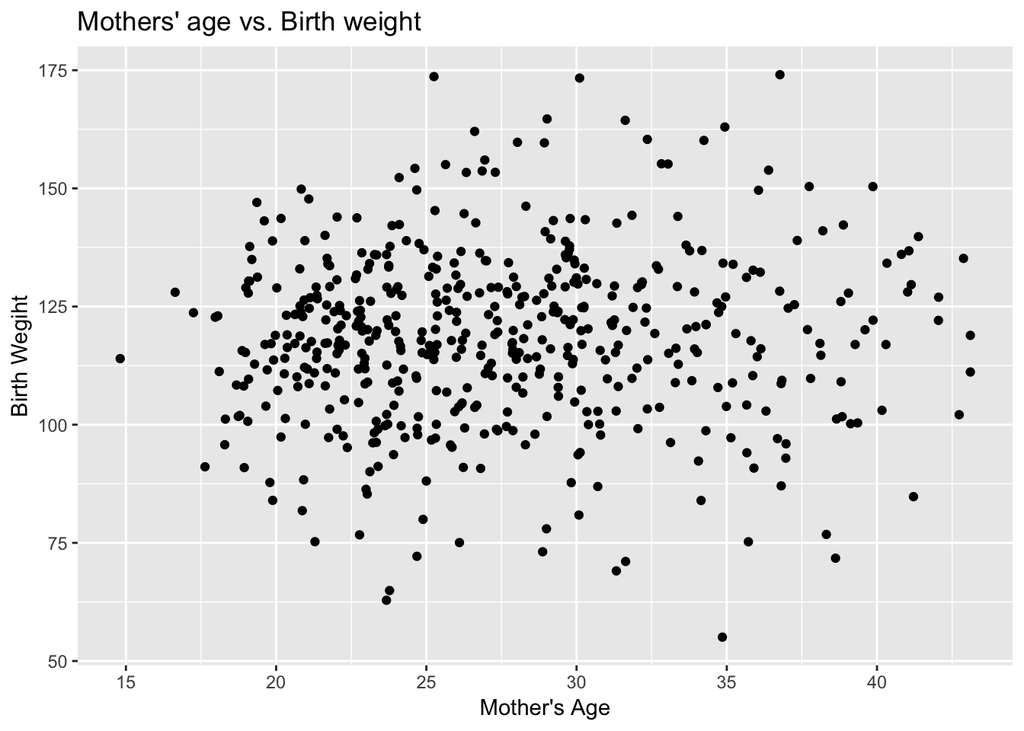

- I created this plot using geom_jitter to compare a mother’s age vs their birth weight. I set x = mother’s age and y = birth weight in aesthetic. I used ggtitle, xlab, and ylab to label all axis and the graph.
- From this graph I found that between ages 20-30, the birth weight is more consistent. Then, after age 30, the graph shows that birth weight is less consistant.

### Ethan’s Graph

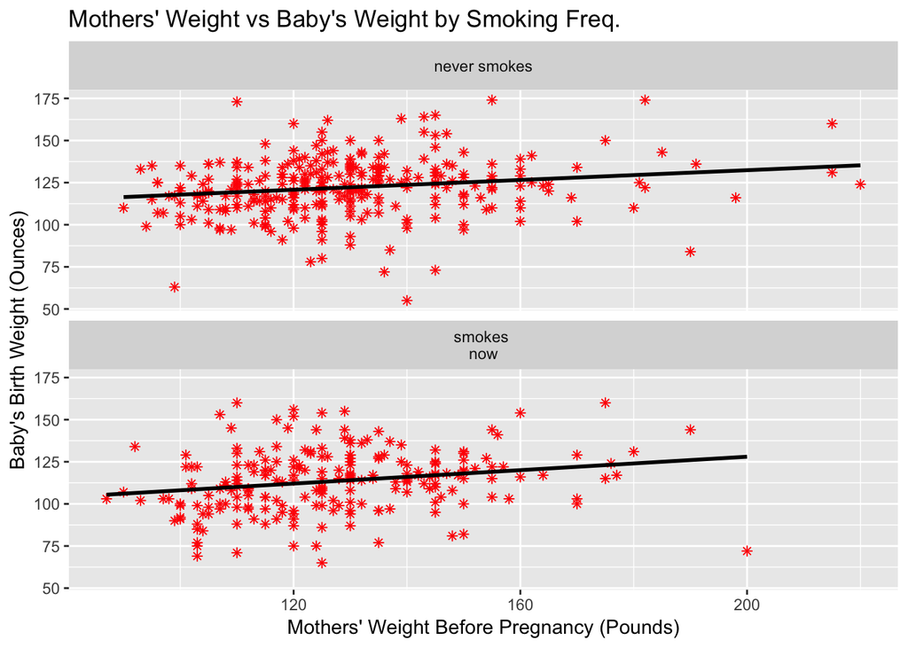

- I created this graph using geom_point and geom_smooth to plot mothers’ weights before pregnancy vs babys’ birth weights. I also used facets to separate this correlation by smoking habits to see if smoking affected the correlation between the two weights. I used xlab, ylab, ggtitle, subtitle, and non-default colors and shapes to enhance my graph’s aesthetic appeal.
- I found that there is a minor positive correlation between mothers’ pre-pregnancy weights and babys’ birth weights. However, whether or not the mom never smokes or smokes now has no affect on this correlation.

### Ryan’s Graph

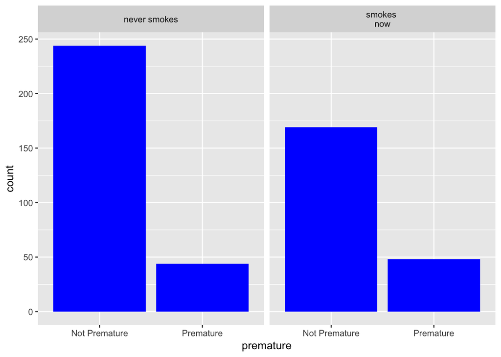

### Anderson’s Graph

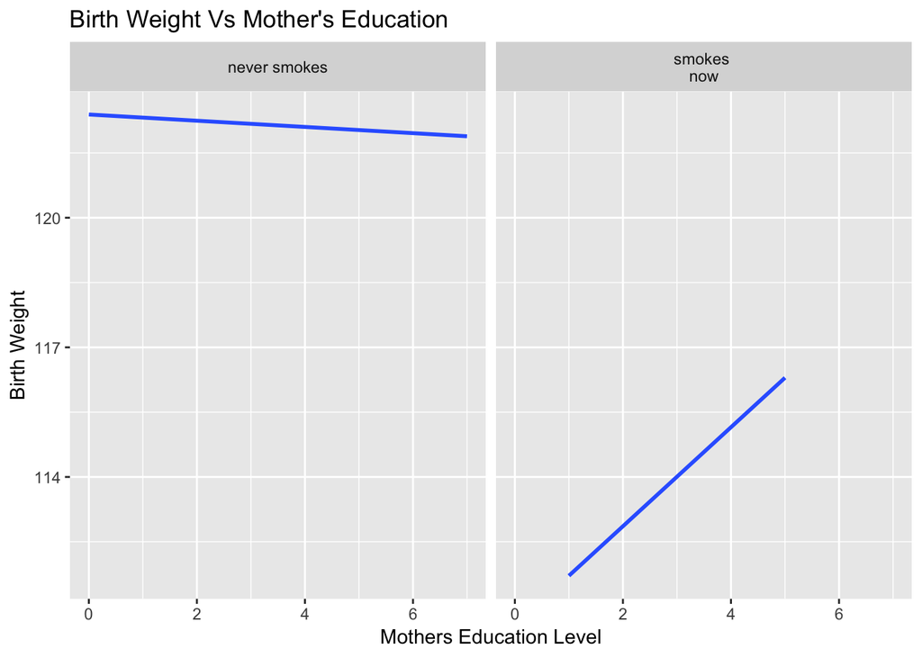

### Main questions and Importance:

- “Do mothers’ smoking habits affect the presence of premature births?” and “Do mothers’ smoking habits affect the correlation between their babys’ gestational age and birth weight?”
- These questions are important because answering them will allow us to provide recommendations to mothers on whether or not smoking is hurtful for their newborn babies. Most parents care deeply about the well-being of their babies, who contain fragile health, making this statistical study very relevant and important.

### Team Plot #1

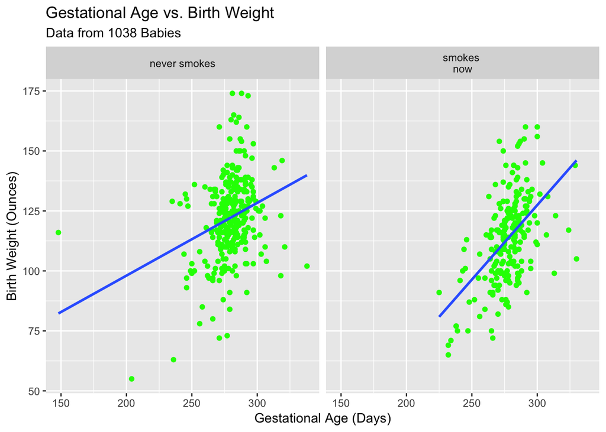

- Findings: This graph answers our second main question, which is “Do mothers’ smoking habits affect the correlation between their babys’ gestational age and birth weight?” The surgeon general’s assumption was that newborns of mothers who smoke have smaller birth weights as gestational age rises than newborns of mothers who don’t smoke. This graph appears to prove otherwise because the smoker line of best fit has a steeper positive slope than the non-smoker line of best fit, meaning birth weight increases as gestational age rises at a slightly faster rate for newborns of mothers who smoke. Overall, there is a near- moderate positive correlation between gestational age and birth weight at an R value of 0.393.

### Team Plot #2

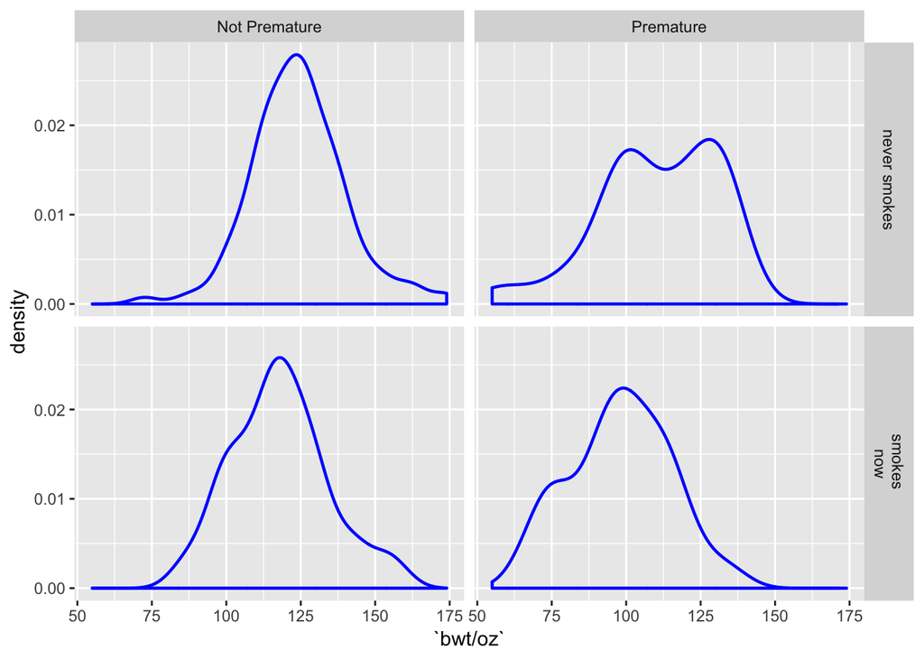

### Preliminary Question Plots

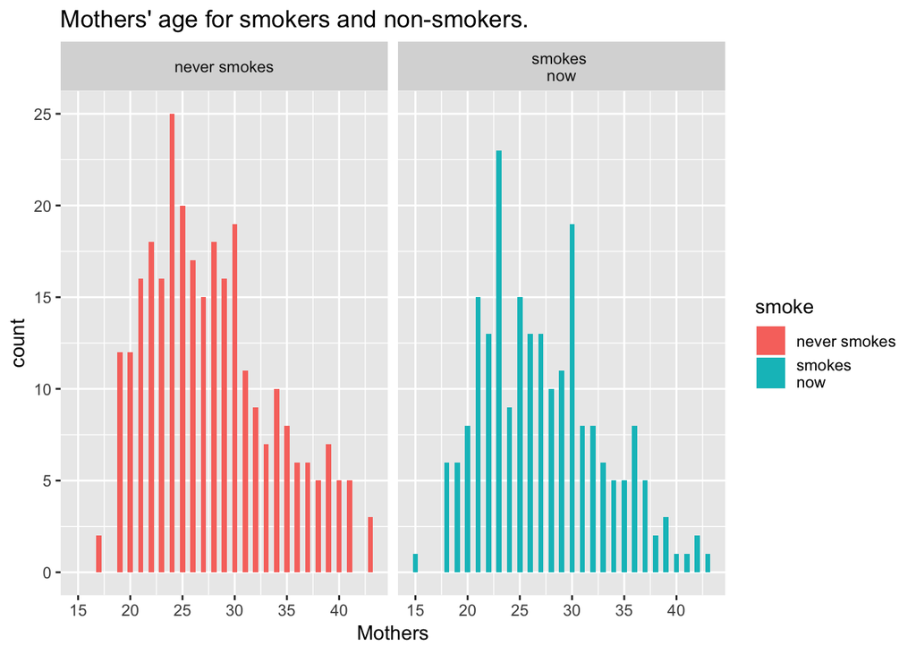

- This graph compares the age at which mothers gave birth and seperates them into smokers and non-smokers.
- The graph is useful for seeing if age has any indicator on whether or not a mother will be more likely to smoke will pregnant if she is older or younger.

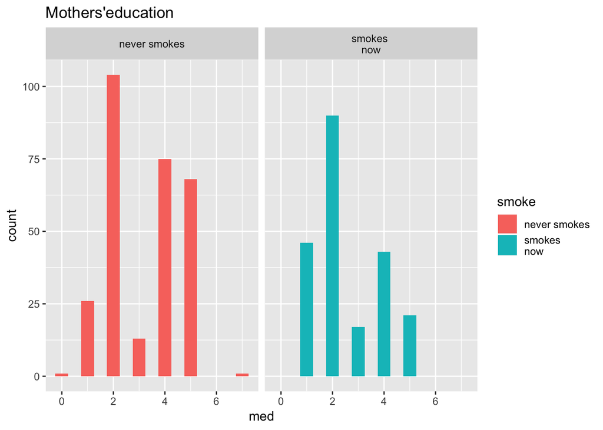

* This graph compares the education of mothers who smoked while pregnant.

- The graph could be useful for deciding if mothers were more likely to smoke while pregnant if they had less of an education, or a different type of education.

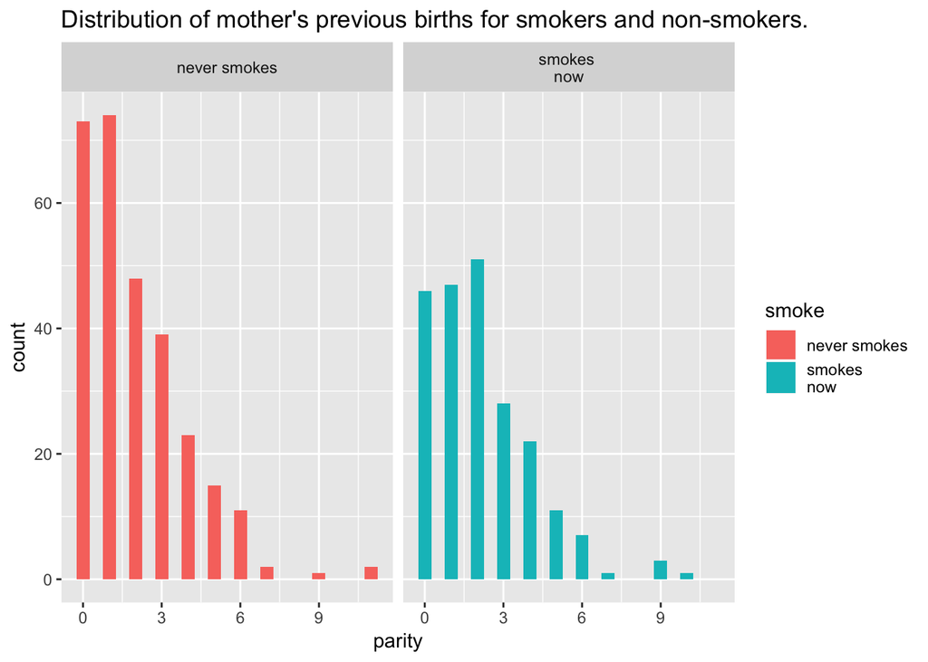

- This graph divides mothers into groups depending on the amount of times they have given birth and trys to examine whether more births led to women not smoking while pregnant.